# chapter3.rmd

Ilse Ekman

18 11 2019

### Exercise 3

## Analysis of the third exercise

```r
alc <-read.table("http://s3.amazonaws.com/assets.datacamp.com/production/course_2218/datasets/alc.txt", sep = ",", header = TRUE)
```

**Structure of the data:**

```r
str(alc)
```

```
## 'data.frame':    382 obs. of  35 variables:
##  $ school    : Factor w/ 2 levels "GP","MS": 1 1 1 1 1 1 1 1 1 1 ...
##  $ sex       : Factor w/ 2 levels "F","M": 1 1 1 1 1 2 2 1 2 2 ...
##  $ age       : int  18 17 15 15 16 16 16 17 15 15 ...
##  $ address   : Factor w/ 2 levels "R","U": 2 2 2 2 2 2 2 2 2 2 ...
##  $ famsize   : Factor w/ 2 levels "GT3","LE3": 1 1 2 1 1 2 2 1 2 1 ...
##  $ Pstatus   : Factor w/ 2 levels "A","T": 1 2 2 2 2 2 2 1 1 2 ...
##  $ Medu      : int  4 1 1 4 3 4 2 4 3 3 ...
##  $ Fedu      : int  4 1 1 2 3 3 2 4 2 4 ...
##  $ Mjob      : Factor w/ 5 levels "at_home","health",..: 1 1 1 2 3 4 3 3 4 3 ...
##  $ Fjob      : Factor w/ 5 levels "at_home","health",..: 5 3 3 4 3 3 3 5 3 3 ...
##  $ reason    : Factor w/ 4 levels "course","home",..: 1 1 3 2 2 4 2 2 2 2 ...
##  $ nursery   : Factor w/ 2 levels "no","yes": 2 1 2 2 2 2 2 2 2 2 ...
##  $ internet  : Factor w/ 2 levels "no","yes": 1 2 2 2 1 2 2 1 2 2 ...
##  $ guardian  : Factor w/ 3 levels "father","mother",..: 2 1 2 2 1 2 2 2 2 2 ...
```

[output cut: 21 more lines]

This data is a combined data from two datasets regarding the performance in mathematics and Portuguese language.

The data has 382 observations of 35 variables.

**The names of the variables:**

```r
colnames(alc)
```

```
##  [1] "school"     "sex"        "age"        "address"    "famsize"
##  [6] "Pstatus"    "Medu"       "Fedu"       "Mjob"       "Fjob"
## [11] "reason"     "nursery"    "internet"   "guardian"   "traveltime"
## [16] "studytime"  "failures"   "schoolsup"  "famsup"     "paid"
## [21] "activities" "higher"     "romantic"   "famrel"     "freetime"
## [26] "goout"      "Dalc"       "Walc"       "health"     "absences"
## [31] "G1"         "G2"         "G3"         "alc_use"    "high_use"
```

**The purpose of my analysis is to study the relationship between alcohol consumption and following four variables:**

**1.sex: I hypothese that male students have higher consumption of alcohol.**

**2.age: I hypothese that the older the student is the more they consume alcohol.**

**3.goout: I hypothese that the more the student goes out with friends the bigger their alcohol consumption is.**

**4.health: I hypothese that the current health status is worse in the students with higher alcohol consumption.**

**Exploring the first hypothesis:**

```r
library(dplyr); library(ggplot2)
alc %>% group_by(sex, high_use) %>% summarise(count = n())
```

```
## # A tibble: 4 x 3
## # Groups:   sex [2]
##   sex   high_use count
##   <fct> <lgl>    <int>
## 1 F     FALSE      157
## 2 F     TRUE        41
## 3 M     FALSE      113
## 4 M     TRUE        71
```

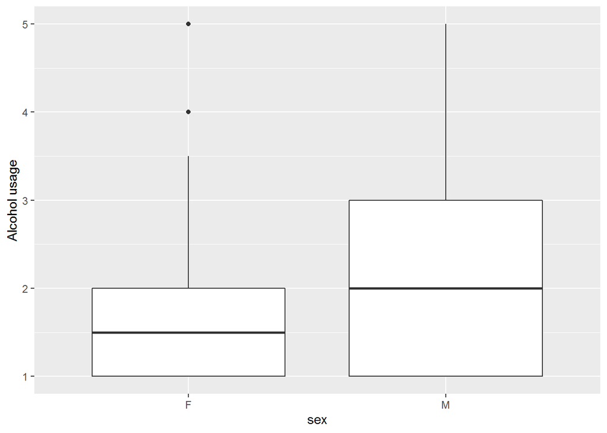

```r
g1 <- ggplot(alc, aes(x = sex, y = alc_use))
g1 + geom_boxplot() + ylab("Alcohol usage")
```

**Exploring the second hypothesis:**

```r
alc %>% group_by(age, high_use) %>% summarise(count = n())
```

```
## # A tibble: 12 x 3
## # Groups:   age [7]
##      age high_use count
##    <int> <lgl>    <int>
##  1    15 FALSE       63
##  2    15 TRUE        18
##  3    16 FALSE       79
##  4    16 TRUE        28
##  5    17 FALSE       65
##  6    17 TRUE        35
##  7    18 FALSE       55
##  8    18 TRUE        26
##  9    19 FALSE        7
## 10    19 TRUE         4
## 11    20 FALSE        1
## 12    22 TRUE         1
```

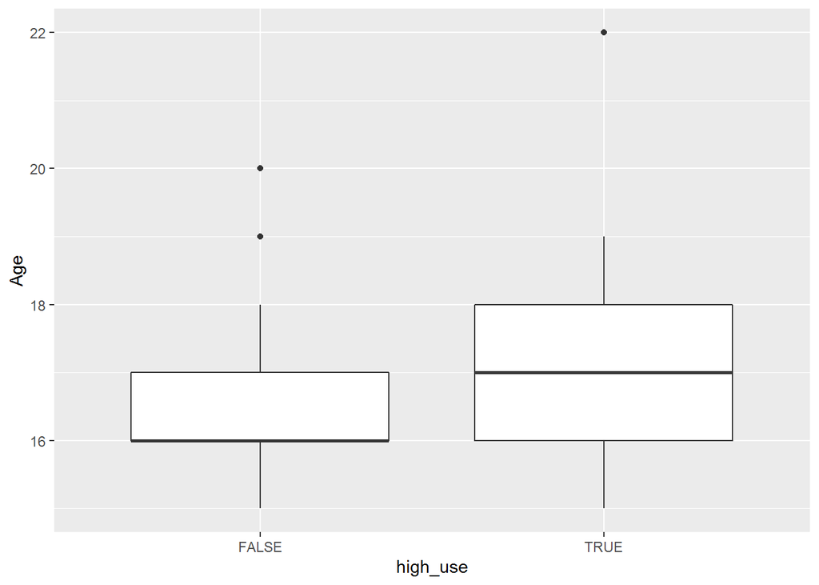

```r
g2 <- ggplot(alc, aes(x = high_use, y = age))
g2 + geom_boxplot() + ylab("Age")
```

**Exploring the third hypothesis:**

```r
alc %>% group_by(goout, high_use) %>% summarise(count = n())
```

```
## # A tibble: 10 x 3
## # Groups:   goout [5]
##    goout high_use count
##    <int> <lgl>    <int>
##  1     1 FALSE       21
##  2     1 TRUE         3
##  3     2 FALSE       84
##  4     2 TRUE        15
##  5     3 FALSE      100
##  6     3 TRUE        23
##  7     4 FALSE       43
##  8     4 TRUE        39
##  9     5 FALSE       22
## 10     5 TRUE        32
```

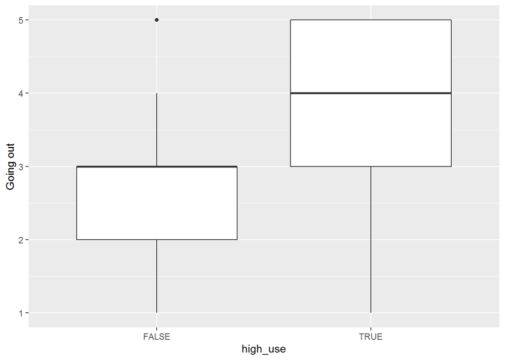

```r
g3 <- ggplot(alc, aes(x = high_use, y = goout))
g3 + geom_boxplot() + ylab("Going out")
```

**Exploring the fourth hypothesis:**

```r
alc %>% group_by(health, high_use) %>% summarise(count = n())
```

```
## # A tibble: 10 x 3
## # Groups:   health [5]
##    health high_use count
##     <int> <lgl>    <int>
##  1      1 FALSE       35
##  2      1 TRUE        11
##  3      2 FALSE       29
##  4      2 TRUE        14
##  5      3 FALSE       63
##  6      3 TRUE        20
##  7      4 FALSE       47
##  8      4 TRUE        17
##  9      5 FALSE       96
## 10      5 TRUE        50
```

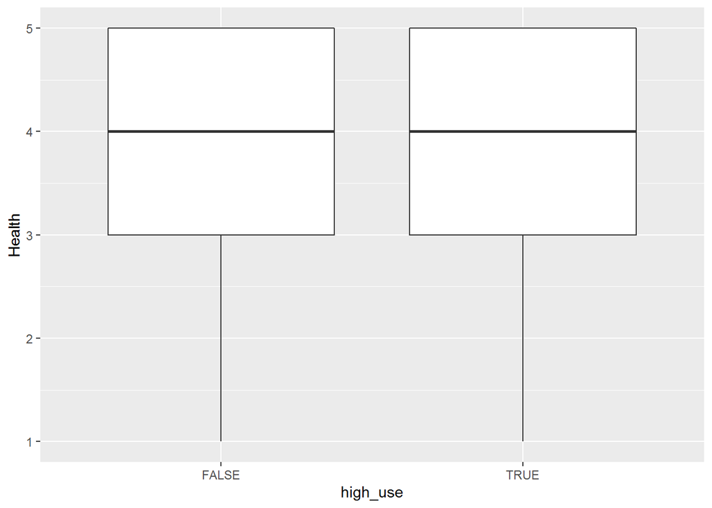

```r
g4 <- ggplot(alc, aes(x = high_use, y = health))
g4 + geom_boxplot() + ylab("Health")
```

**Exploring the variables with logistic regression:**

```r
m <- glm(high_use ~ sex + age + goout + health, data = alc, family = "binomial")

summary(m)
```

```
##
## Call:
## glm(formula = high_use ~ sex + age + goout + health, family = "binomial",
##     data = alc)
##
## Deviance Residuals:
##     Min       1Q   Median       3Q      Max
## -1.6588  -0.8201  -0.5777   0.8775   2.5750
##
## Coefficients:
##             Estimate Std. Error z value Pr(>|z|)
## (Intercept) -6.11487    1.83697  -3.329 0.000872 ***
## sexM         0.85484    0.25138   3.401 0.000672 ***
## age          0.12110    0.10626   1.140 0.254400
## goout        0.73941    0.11854   6.238 4.44e-10 ***
## health       0.09356    0.09067   1.032 0.302106
## ---
## Signif. codes:  0 '***' 0.001 '**' 0.01 '*' 0.05 '.' 0.1 ' ' 1
##
## (Dispersion parameter for binomial family taken to be 1)
##
##     Null deviance: 462.21  on 381  degrees of freedom
## Residual deviance: 397.09  on 377  degrees of freedom
## AIC: 407.09
##
## Number of Fisher Scoring iterations: 4
```

```r
coef(m)
```

```
## (Intercept)        sexM         age       goout      health
## -6.11486907  0.85484147  0.12110491  0.73941072  0.09356162
```

**To compute out odds ratios:**

```r
OR <- coef(m) %>% exp
```

**To compute out confidence intervals:**

```r
CI <- confint(m) %>% exp
cbind(OR, CI)
```

```
##                      OR        2.5 %     97.5 %
## (Intercept) 0.002209765 5.593849e-05 0.07655548
## sexM        2.351001643 1.442941e+00 3.87351253
## age         1.128743323 9.171918e-01 1.39274305
## goout       2.094700778 1.670317e+00 2.66104027
## health      1.098078261 9.206963e-01 1.31483045
```

**To predict the probability of high alcohol usage:**

probabilities <- predict(m, type = “response”)

alc <- mutate(alc, probability = probabilities)

alc <- mutate(alc, prediction = probability > 0.5)